# Sentiment Analysis

Audrey Pentz

September 20, 2018

## **Load the Preprocessed Data**

```r
load("../input_data.RData")
```

## **Remove Stop Words and Tokenize by Sentences, Words and Bigrams**

```r
# sentence tokenization
tidy_sona_sentences <- input_data$sentences

# word tokenization
tidy_sona_words <- input_data$words %>%
  filter(!word %in% stop_words$word, str_detect(word, "[a-z]"))  # remove stop words

# bigram tokenization
bigrams <- tidy_sona_sentences %>%
  unnest_tokens(bigram, sentence, token = "ngrams", n = 2)
# separate the bigrams
bigrams_separated <- bigrams %>%
  separate(bigram, c("word1", "word2"), sep = " ")
# remove stop words
bigrams_filtered <- bigrams_separated %>%
  filter(!word1 %in% stop_words$word) %>%
  filter(!word2 %in% stop_words$word)
# join up the bigrams again
tidy_sona_bigrams <- bigrams_filtered %>%
  unite(bigram, word1, word2, sep = " ")
```

## **Analysis of Sentiment using Single Words**

### **Sentiment Analysis using “bing” lexicon**

The “bing” lexicon encodes words as either “positive” or “negative”. However, not all words used in the SONA speeches are in the lexicon so we need to adjust for this.

#### **Sentiment per President**

Let’s understand how many “positive” and “negative” words are used by each president across all their SONA speeches and create a metric called “sentiment” which is simply the total number of positive words minus the total number of negative words. We then adjust for the total number of words used from the lexicon in the “sentiment_score” metric.

```r
# average sentiment per president
avg_sentiment <- tidy_sona_words %>%
  inner_join(get_sentiments("bing")) %>%
  group_by(president) %>%
  count(sentiment) %>%
  spread(sentiment, n, fill = 0) %>%
  mutate(sentiment = positive - negative,
         sentiment_score = round( (sentiment / (positive + negative) * 100), 2)) %>%
  arrange(desc(sentiment_score))
```

```r
# plot avg words per president
avg_sentiment %>%
  ungroup(sentiment_score, president) %>%
  mutate(sentiment_score = color_bar("lightblue")(sentiment_score)) %>%
  kable("html", escape = FALSE, align = "l", caption = "Sentiment Score per President") %>%
  kable_styling(bootstrap_options =
                  c("striped", "condensed", "bordered"),
                  full_width = FALSE)
```

Sentiment Score per President

| president | negative | positive | sentiment | sentiment_score |
| --- | --- | --- | --- | --- |
| Zuma | 788 | 1466 | 678 | 30.08 |
| Ramaphosa | 102 | 181 | 79 | 27.92 |
| Mbeki | 1314 | 2287 | 973 | 27.02 |
| Motlanthe | 180 | 263 | 83 | 18.74 |
| Mandela | 1036 | 1434 | 398 | 16.11 |
| deKlerk | 64 | 58 | -6 | -4.92 |

**Insights:**

Of the 3 presidents that have made more than 1 SONA speech, Zuma has the highest sentiment score, followed by Mbeki and then Mandela. Zuma’s sentiment score is nearly double Mandela’s. It’s interesting that the current President, Ramaphosa, has the second highest sentiment score, not far behind Zuma and only slightly ahead of Mbeki.

#### **What are the 10 positive words most frequently used by each president?**

```r
positive_words <- tidy_sona_words %>%
  group_by(president) %>%
  inner_join(get_sentiments("bing")) %>%
  filter(sentiment == "positive") %>%
  count(word) %>%
  arrange(desc(n)) %>%
  group_by(president) %>%
  slice(seq_len(10)) %>%
  ungroup() %>%
  arrange(president, n) %>%
  mutate(row = row_number())
```

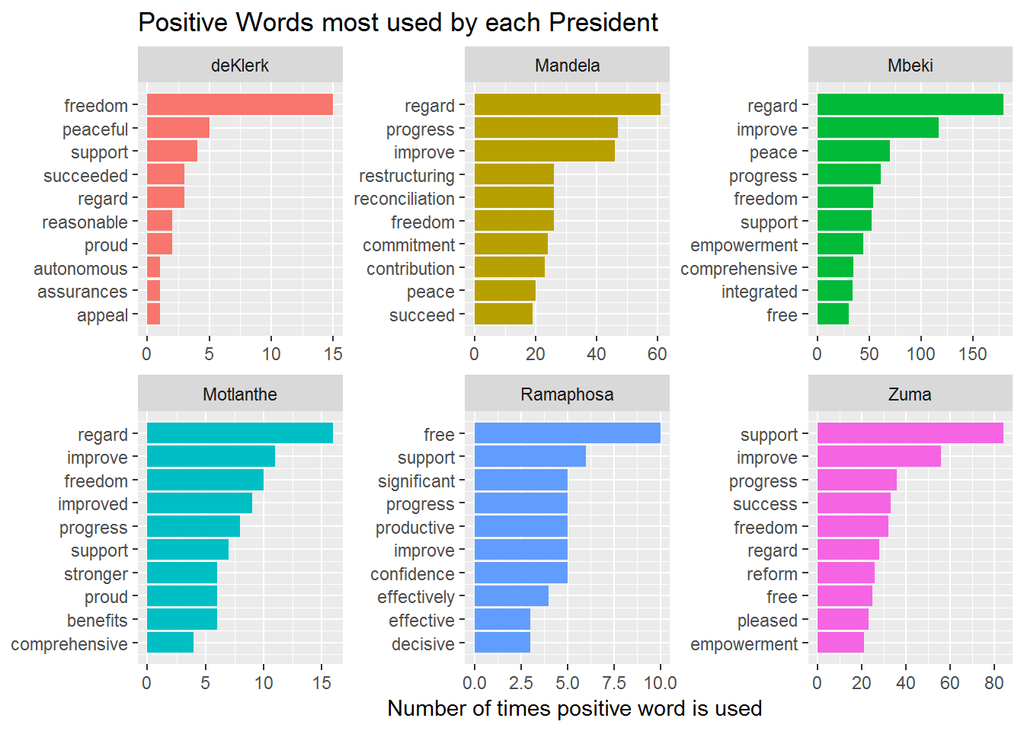

```r
positive_words %>%
  ggplot(aes(x = row, n, fill = president)) +
    geom_col(show.legend = NULL) +
    labs(x = NULL, y = "Number of times positive word is used") +
    ggtitle("Positive Words most used by each President") +
    facet_wrap(~president,
               ncol = 3, nrow = 3,
               scales = "free") +
    scale_x_continuous(
      breaks = positive_words$row,
      labels = positive_words$word) +
    coord_flip()
```

**Insights:**

#### **Which of the positive words most frequently used are common across presidents?**

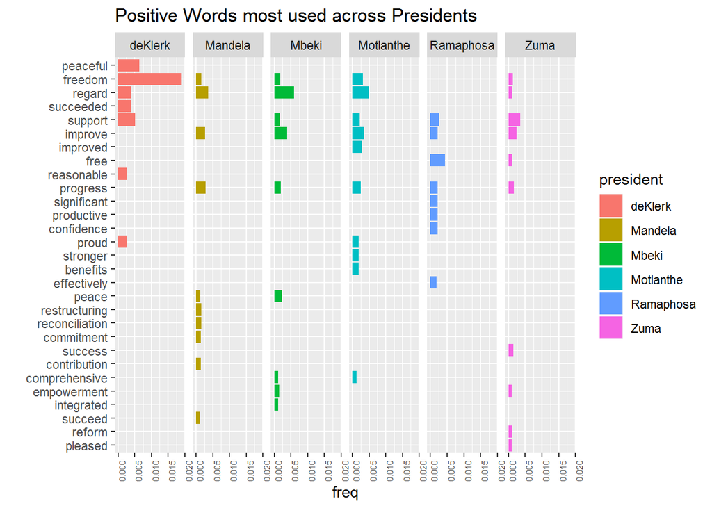

```r
total_speeches <- tidy_sona_words %>%
                 group_by(president) %>%
                 summarise(total = n())

tidy_sona_words %>%
  inner_join(get_sentiments("bing")) %>%
  filter(sentiment == "positive") %>%
  group_by(president) %>%
  count(word, sort = TRUE) %>%
  left_join(total_speeches) %>%
  mutate(freq = n/total) %>%
  filter(rank(desc(freq)) <= 10) %>%
  ggplot(aes(reorder(word,freq), freq, fill = president)) +
  geom_col() +
  coord_flip() +
  xlab("") +
  facet_grid(.~ president) +
  ggtitle("Positive Words most used across Presidents") +
  theme(axis.text.x=element_text(size=6, angle = 90))
```

**Insights:**

#### **What are the 10 negative words most used by each president?**

```r
negative_words <- tidy_sona_words %>%
  group_by(president) %>%
  inner_join(get_sentiments("bing")) %>%
  filter(sentiment == "negative") %>%
  count(word) %>%
  arrange(desc(n)) %>%
  group_by(president) %>%
  slice(seq_len(10)) %>%
  ungroup() %>%
  arrange(president, n) %>%
  mutate(row = row_number())
```

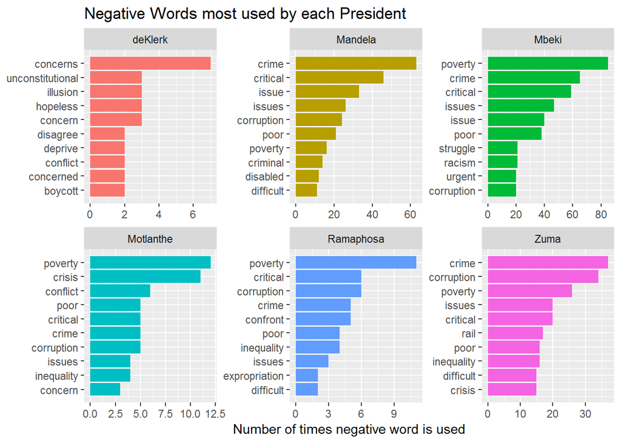

```r
negative_words %>%
  ggplot(aes(x = row, n, fill = president)) +
    geom_col(show.legend = NULL) +
    labs(x = NULL, y = "Number of times negative word is used") +
    ggtitle("Negative Words most used by each President") +
    facet_wrap(~president,
               ncol = 3, nrow = 3,
               scales = "free") +
    scale_x_continuous(
      breaks = negative_words$row,
      labels = negative_words$word) +
    coord_flip()
```

**Insights:**

Common negative words pre 1994 include: “concerns”/“concern”/“concerned”, “unconstitutional”, “illusion”, “hopeless”, “disagree”, “deprive”, “conflict”, and “boycott”.

Common negative words post 1994 include: “corruption”, “crime”/“criminal”, “poverty”/“poor”, “inequality”, “issue”/“issues” and “crisis”.

#### **How many of the negative words most used were used by each president?**

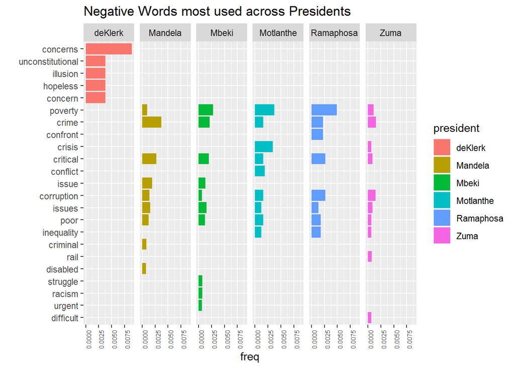

```r
tidy_sona_words %>%
  inner_join(get_sentiments("bing")) %>%
  filter(sentiment == "negative") %>%
  group_by(president) %>%
  count(word, sort = TRUE) %>%
  left_join(total_speeches) %>%
  mutate(freq = n/total) %>%
  filter(rank(desc(freq)) <= 10) %>%
  ggplot(aes(reorder(word,freq), freq, fill = president)) +
  geom_col() +
  coord_flip() +
  xlab("") +
  facet_grid(.~ president) +
  ggtitle("Negative Words most used across Presidents") +
  theme(axis.text.x=element_text(size=6, angle = 90))
```

**Insights:**

The interpretation is much the same as before. Note the clear separation between the top 10 negative words used pre and post 1994 elections, indicative of the pre and post apartheid regimes.

#### **What proportion of words used are positive vs negative?**

```r
sentiments_per_year <- tidy_sona_words %>%
  inner_join(get_sentiments("bing")) %>%
  group_by(year, sentiment) %>%
  summarize(n = n())
sentiments_relative <- sentiments_per_year %>%
  left_join(sentiments_per_year %>%
            group_by(year) %>%
            summarise(total = sum(n))) %>%
  mutate(freq = n/total)
```

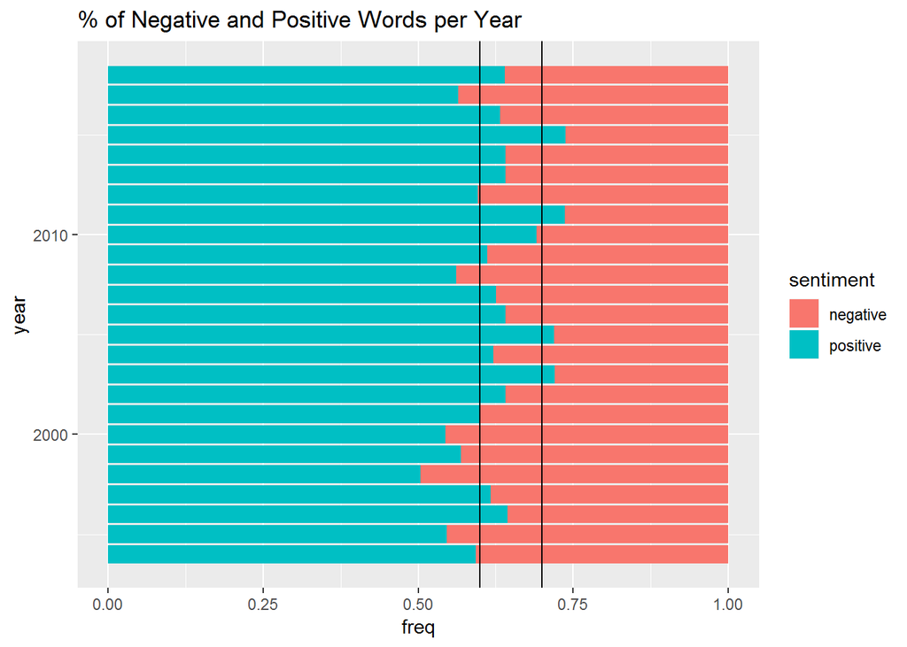

```r
# plot proportion of positive and negative words used
ggplot(filter(sentiments_relative), aes(x = year, y = freq, fill = sentiment)) +
  geom_col() + coord_flip() + ggtitle("% of Negative and Positive Words per Year") +
  geom_hline(yintercept = 0.60) +
  geom_hline(yintercept = 0.70)
```

**Insights:**

The 2 vertical black lines are drawn at 60% amd 70% positivity rates. In the majority of years, SONA speeches fall within this range of positivity however a there are a few more negative speeches in earlier years and a few more positive speeches in later years.

### **Change in Sentiment over time**

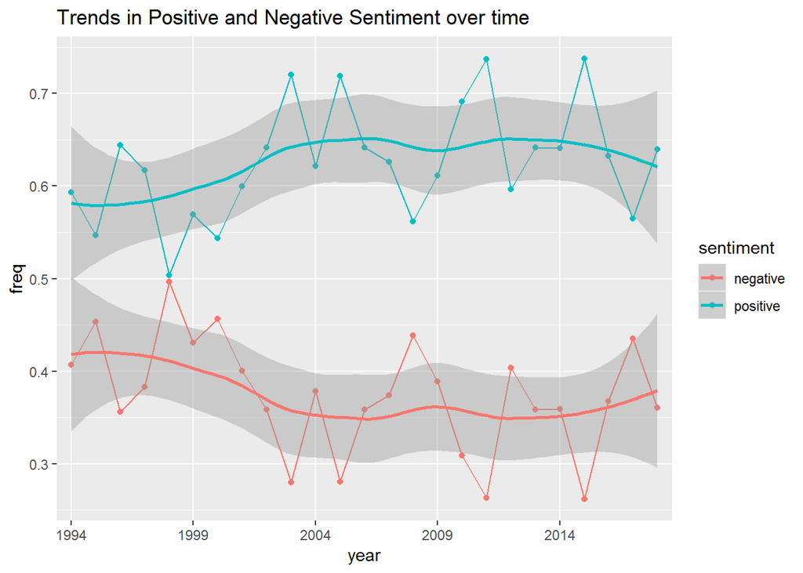

```r
sentiments_relative %>%
  ggplot(aes(x = as.numeric(year), y = freq, colour = sentiment)) +
  geom_point() + geom_line() +
  geom_smooth(method = "loess", aes(colour = sentiment)) +
  ggtitle("Trends in Positive and Negative Sentiment over time") +
  scale_x_discrete(name ="year",
                    limits=c(1994,1999,2004,2009,2014))
```

**Insights:**

The trend appears to be more positive and less negative over time but how can we be sure?

We will test whether negative sentiment is increasing or decreasing, then we will test whether positive sentment is increasing or decreasing . We will use a Binomial model because the frequencies are between 0 and 1. Finally, we will test whether average sentiment is increasing or decreasing using a linear model.

#### **Is negative sentiment increasing over time?**

```r
model_neg <- glm( freq ~ as.numeric(year), data = subset(sentiments_relative, sentiment == "negative"), family = "binomial")
summary(model_neg)
```

```
##
## Call:
## glm(formula = freq ~ as.numeric(year), family = "binomial", data = subset(sentiments_relative,
##     sentiment == "negative"))
##
## Deviance Residuals:
##      Min        1Q    Median        3Q       Max
## -0.21779  -0.05759   0.01224   0.07113   0.19692
##
## Coefficients:
##                   Estimate Std. Error z value Pr(>|z|)
## (Intercept)       25.88105  115.18655   0.225    0.822
## as.numeric(year)  -0.01316    0.05743  -0.229    0.819
##
## (Dispersion parameter for binomial family taken to be 1)
##
##     Null deviance: 0.39087  on 24  degrees of freedom
## Residual deviance: 0.33826  on 23  degrees of freedom
## AIC: 27.484
##
## Number of Fisher Scoring iterations: 3
```

**Insights:**

The slope is negative but the beta of the year variable is not significant so we cannot conclude that negative sentiment is decreasing over time.

#### **Is postive sentiment increasing over time?**

```r
model_pos <- glm( freq ~ as.numeric(year), data = subset(sentiments_relative, sentiment == "positive"), family = "binomial")
summary(model_pos)
```

```
##
## Call:
## glm(formula = freq ~ as.numeric(year), family = "binomial", data = subset(sentiments_relative,
##     sentiment == "positive"))
##
## Deviance Residuals:
##      Min        1Q    Median        3Q       Max
## -0.19692  -0.07113  -0.01224   0.05759   0.21779
##
## Coefficients:
##                   Estimate Std. Error z value Pr(>|z|)
## (Intercept)      -25.88105  115.18655  -0.225    0.822
## as.numeric(year)   0.01316    0.05743   0.229    0.819
##
## (Dispersion parameter for binomial family taken to be 1)
##
##     Null deviance: 0.39087  on 24  degrees of freedom
## Residual deviance: 0.33826  on 23  degrees of freedom
## AIC: 27.484
##
## Number of Fisher Scoring iterations: 3
```

**Insights:**

The slope is positive but the beta of the year variable is not significant so we cannot conclude that positive sentiment is increasing over time.

#### **Is average sentiment increasing over time?**

```r
sentiments_per_year <- tidy_sona_words %>%
  inner_join(get_sentiments("bing")) %>%
  group_by(year, president) %>%
  count(sentiment) %>%
  spread(key = sentiment, value = n) %>%
  mutate(sentiment = positive - negative,
         avg_sentiment = sentiment / (positive + negative) * 100)
model_avg <- glm( avg_sentiment ~ as.numeric(year), data = sentiments_per_year, family = "gaussian")
summary(model_avg)
```

```
##
## Call:
## glm(formula = avg_sentiment ~ as.numeric(year), family = "gaussian",
##     data = sentiments_per_year)
##
## Deviance Residuals:
##     Min       1Q   Median       3Q      Max
## -21.252   -7.877   -1.282    8.584   21.444
##
## Coefficients:
##                    Estimate Std. Error t value Pr(>|t|)
## (Intercept)      -1369.9476   652.4104  -2.100   0.0460 *
## as.numeric(year)     0.6952     0.3253   2.137   0.0425 *
## ---
## Signif. codes:  0 '***' 0.001 '**' 0.01 '*' 0.05 '.' 0.1 ' ' 1
##
## (Dispersion parameter for gaussian family taken to be 153.4216)
##
##     Null deviance: 4536.4  on 26  degrees of freedom
## Residual deviance: 3835.5  on 25  degrees of freedom
## AIC: 216.44
##
## Number of Fisher Scoring iterations: 2
```

**Insights:**

But we need to be cautious with this interpretation because what could actually be going on here is that the “bing”" lexicon has more than double the number of negative words than positive words so this could be influencing the results and SONA speeches may in fact be more positive than they appear to be.

```r
table(get_sentiments('bing')$sentiment)
```

```
##
## negative positive
##     4782     2006
```

#### **Distribution of “bing” Sentiment per President**

```r
# per year, per president
sentiments_per_year <- tidy_sona_words %>%
  inner_join(get_sentiments("bing")) %>%
  group_by(year, president) %>%
  count(sentiment) %>%
  spread(key = sentiment, value = n) %>%
  mutate(sentiment = positive - negative,
         avg_sentiment = sentiment / (positive + negative) * 100)
```

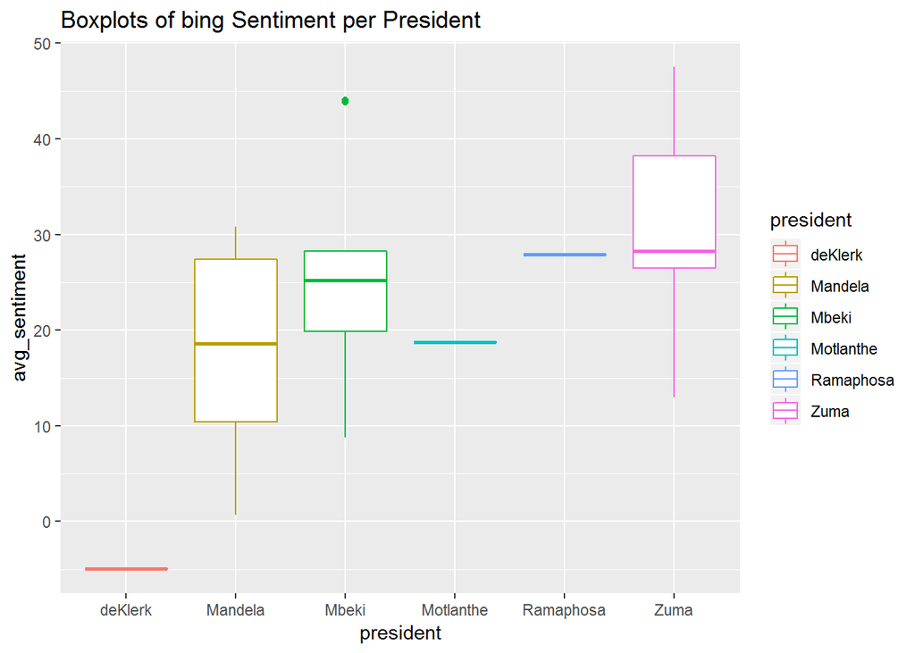

```r
# plot of sentiment by president
ggplot(sentiments_per_year, aes(x = president, y = avg_sentiment, colour = president)) +
  geom_boxplot() + # draw a boxplot for each president
  ggtitle("Boxplots of bing Sentiment per President")
```

**Insights:**

Apart from the last 2 presidents, Ramaphosa and Zuma, the presidents are in time order. We can see that other than Motlanthe, the trend is an increasing average sentiment over time but at a decreasing rate. The interquartile range of Mbeki is smaller than Zuma’s which is smaller than Mandela’s.

#### **Change in “bing” Sentiment over time**

```r
# per year
sentiments_per_year <- tidy_sona_words %>%
  inner_join(get_sentiments("bing")) %>%
  group_by(year, president) %>%
  count(sentiment) %>%
  spread(key = sentiment, value = n) %>%
  mutate(sentiment = positive - negative,
         avg_sentiment = sentiment / (positive + negative) * 100)
```

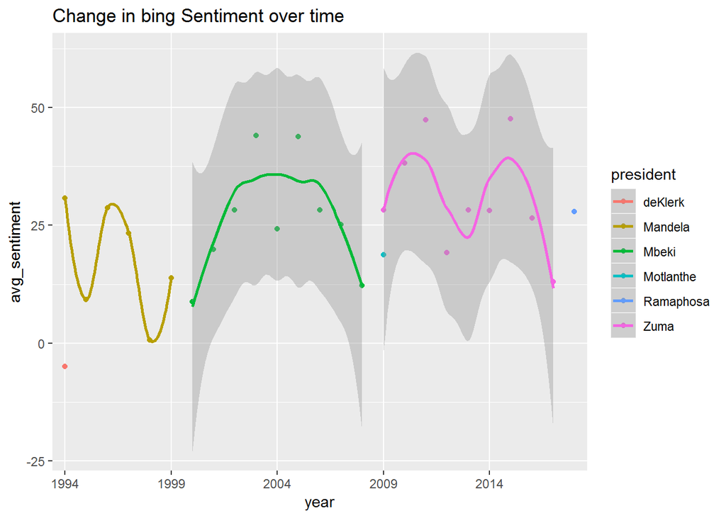

```r
sentiments_per_year %>%
  ggplot(aes(x = as.numeric(year), y = avg_sentiment, colour = president)) +
  geom_point() +
  geom_smooth(method = "loess", aes(colour = president)) +
  ggtitle("Change in bing Sentiment over time") +
  scale_x_discrete(name ="year",
                    limits=c(1994,1999,2004,2009,2014))
```

**Insights:**

### **Sentiment Analysis using “afinn” lexicon (scale from -5 negative to +5 positive)**

```r
tidy_sona_words %>%
  inner_join(get_sentiments("afinn")) %>%
  count(score) %>%
  mutate(weighted_score = score * n) %>%
  ungroup(weighted_score) %>%
  mutate(weighted_score = color_bar("lightblue")(weighted_score),
         n = color_bar("lightblue")(n)) %>%
  kable("html", escape = FALSE, align = "r", caption = "afinn Sentiment") %>%
  kable_styling(bootstrap_options =
                  c("striped", "condensed", "bordered"),
                  full_width = FALSE)
```

afinn Sentiment

| score | n | weighted_score |
| --- | --- | --- |
| -5 | 2 | -10 |
| -4 | 27 | -108 |
| -3 | 689 | -2067 |
| -2 | 1059 | -2118 |
| -1 | 867 | -867 |
| 1 | 2422 | 2422 |
| 2 | 3525 | 7050 |
| 3 | 379 | 1137 |
| 4 | 42 | 168 |
| 5 | 32 | 160 |

**Insights:**

The most number of words are scored positive 2, followed by positive 1. This becomes even more pronounced when scores are multiplied by counts to get weighted scores.

Let’s check the distribution of all “afinn” words:

```r
table(get_sentiments('afinn')$score)
```

```
##
##  -5  -4  -3  -2  -1   0   1   2   3   4   5
##  16  43 264 965 309   1 208 448 172  45   5
```

Words with a score of -2 dominate the lexicon, followed by words with a score of 2. We found a relatively high number of words with a score of 2 in this analysis but it is unlikely to only be a result of its prevalence in the lexicon and we can conclude that it is probably an accurate assessment of the sentiment that prevails in the text.

#### **Distribution of “afinn” Sentiment per President**

```r
# per year, per president
sentiments_per_year <- tidy_sona_words %>%
  inner_join(get_sentiments("afinn")) %>%
  group_by(year, president) %>%
  count(score) %>%
  mutate(score = ifelse(is.na(score), 0, score),
         total_words = sum(n),
         afinn_sentiment = sum(score * n),   # weighted score
         afinn_sentiment_perc = round((afinn_sentiment/total_words*100),2)) %>%
         # afinn sentiment as a percentage of total words in the sentence
  spread(key = score, value = n, fill = 0)
```

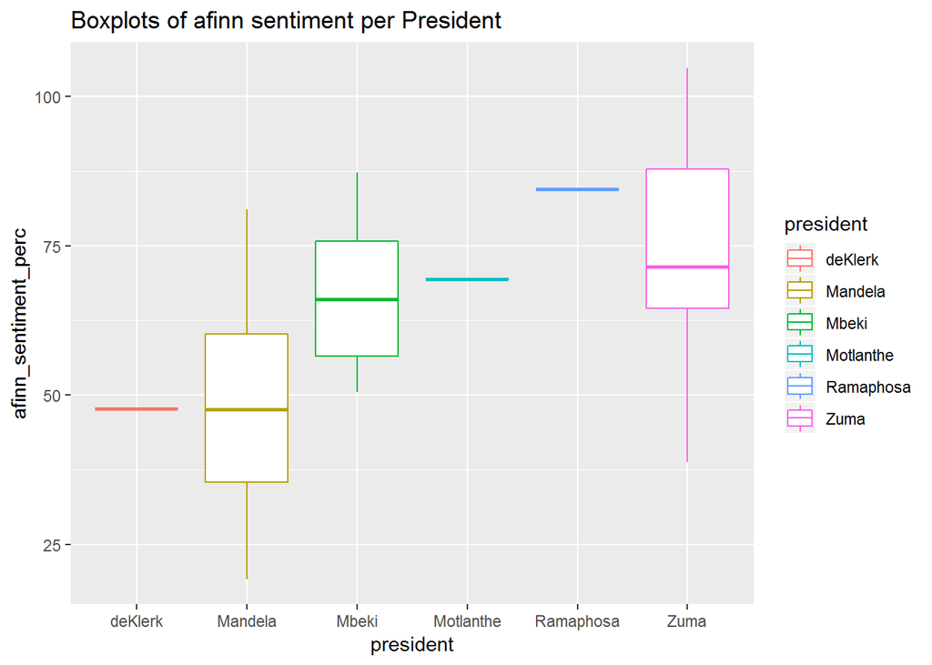

```r
# plot of sentiment by president
ggplot(sentiments_per_year, aes(x = president, y = afinn_sentiment_perc, colour = president)) +   geom_boxplot() + # draw a boxplot for each president
  ggtitle("Boxplots of afinn sentiment per President")
```

**Insights:**

The interpretation is much the same as with the “bing” lexicon in that the trend is an increasing average sentiment over time however Zuma’s median sentiment is lower than the general trend.

#### **Change in “afinn” Sentiment over time**

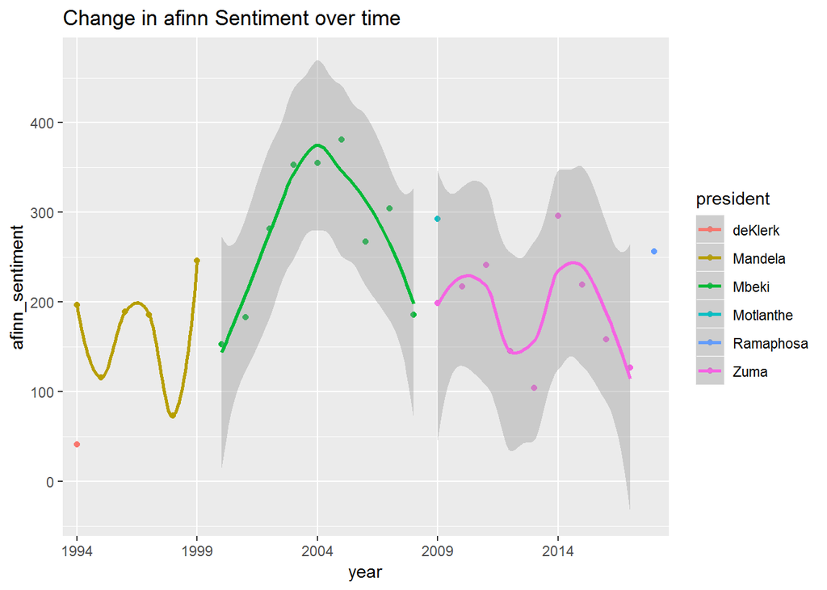

```r
sentiments_per_year %>%
  ggplot(aes(x = as.numeric(year), y = afinn_sentiment, colour = president)) +
  geom_point() +
  geom_smooth(method = "loess", aes(colour = president)) +
  ggtitle("Change in afinn Sentiment over time") +
  scale_x_discrete(name ="year",
                    limits=c(1994,1999,2004,2009,2014))
```

**Insights:**

Mandela and Zuma show a wave-like pattern of sentiment. Mbeki shows an increasing and then decreasing pattern.

### **Sentiment Analysis using “nrc” lexicon (infers emotion with certain words)**

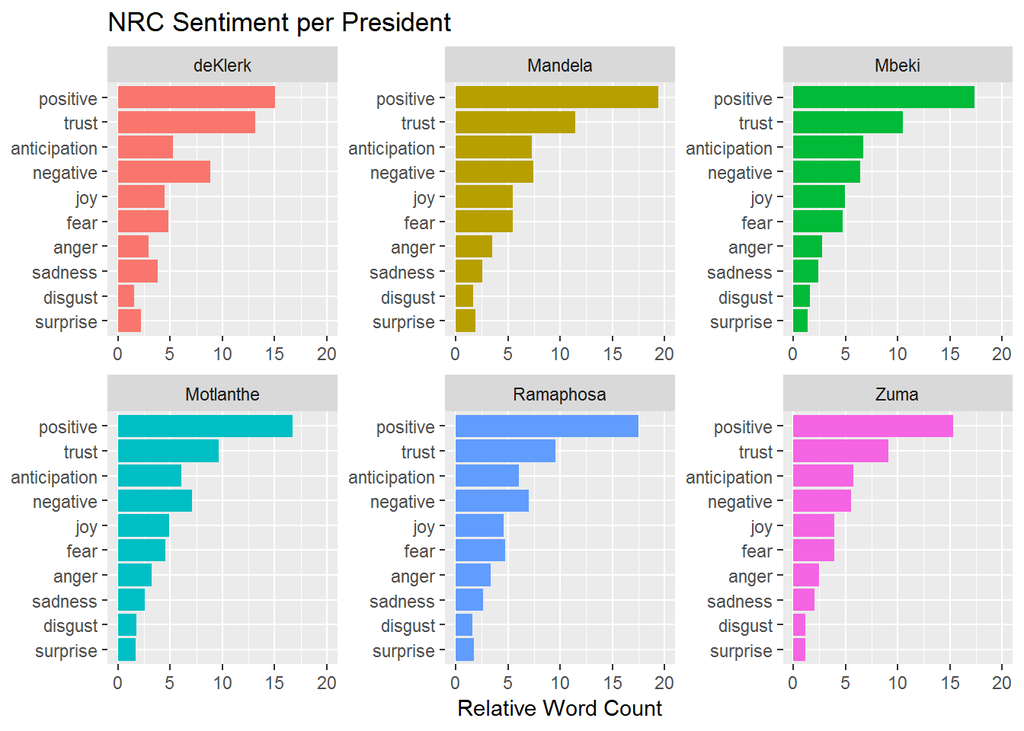

```r
president_total <- tidy_sona_words %>%
  group_by(president) %>%
  count() %>%
  rename(total = n)

# nrc sentiment per president
tidy_sona_words %>%
  inner_join(get_sentiments("nrc")) %>%
  group_by(president, sentiment) %>%
  summarise(word_count = n()) %>%
  left_join(president_total) %>%
  mutate(word_perc = round((word_count/total*100),2)) %>%
  ungroup() %>%
  mutate(sentiment = reorder(sentiment, word_count)) %>%
  ggplot(aes(sentiment, word_perc, fill = president)) +
  facet_wrap(~president,
           ncol = 3, nrow = 3,
           scales = "free") +
  geom_col() +
  guides(fill = FALSE) +                       # turn off the legend
  labs(x = NULL, y = "Relative Word Count") +
  scale_y_continuous(limits = c(0, 20)) +      # hard code the axis limit
  ggtitle("NRC Sentiment per President") +
  coord_flip()
```

Let’s check the distribution of all “nrc” words:

```r
table(get_sentiments('nrc')$sentiment)
```

```
##
##        anger anticipation      disgust         fear          joy
##         1247          839         1058         1476          689
##     negative     positive      sadness     surprise        trust
##         3324         2312         1191          534         1231
```

**Insights:**

Words can be assigned more than 1 sentiment but we do not expect as many words to come up under “anticipation”, “joy” or “surprise” given the relatively lower counts in the lexicon. So “anticipation” has a surprisingly high relative count across all presidents.

### **Sentiment Analysis using “nrc” lexicon**

```r
nrc_sentiment <- tidy_sona_words %>%
  inner_join(get_sentiments("nrc")) %>%
  group_by(sentiment) %>%
  count(word, sort = TRUE) %>%
  arrange(desc(n)) %>%
  slice(seq_len(8)) %>% #consider top_n() from dplyr also
  ungroup()
```

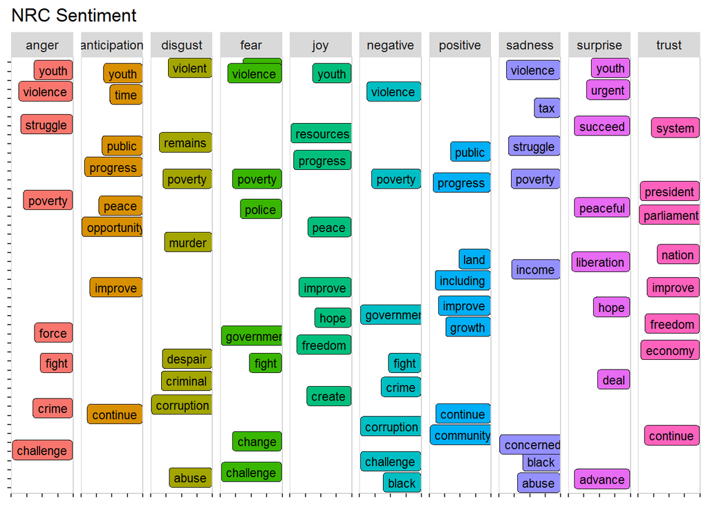

```r
nrc_sentiment %>%
  # set `y = 1` to just plot one variable and use word as the label
  ggplot(aes(word, 1, label = word, fill = sentiment )) +
  # we want the words, not the points
  geom_point(color = "transparent") +
  # make sure the labels don't overlap
  geom_label_repel(force = 1,nudge_y = .5,
                   direction = "y",
                   box.padding = 0.04,
                   segment.color = "transparent",
                   size = 3) +
  facet_grid(~sentiment) +
  theme(axis.text.y = element_blank(), axis.text.x = element_blank(),
        axis.title.x = element_text(size = 6),legend.position="none",
        panel.grid = element_blank(), panel.background = element_blank(),
        panel.border = element_rect("lightgray", fill = NA),
        strip.text.x = element_text(size = 9)) +
  xlab(NULL) + ylab(NULL) +
  ggtitle("NRC Sentiment") +
  coord_flip()
```

**Insights:**

The negative most used words which are also associated with the “anger”, “disgust”, fear" and “sadness” emotions are: “violence”, “struggle” and “poverty”.

The positive most used words which are also associated with the “anticipation”, “joy” and surprise" emotions are: “youth”, “public” and “progress”.

The most usedwords that evoke the “trust” emotion are: “system”, “president”, “parliament” and “nation”.

## **Analysis of Sentiment using Bigrams**

### **Checking for Negation in Bigrams**

It just so happens that the 4 negation words are also stop words so have already been removed from the Bigrams and we need to add them back. This can be shown as follows:

```r
negation_words <- c("not", "no", "never", "without")

x <- which(stop_words$word == "not")      # this includes the pattern for "not"
x <- append(x, which(stop_words$word == "no"), after=length(x))
x <- append(x, which(stop_words$word == "never"), after=length(x))
x <- append(x, which(stop_words$word == "without"), after=length(x))
stop_words$word[x]
```

```
##  [1] "not"     "not"     "not"     "no"      "no"      "no"      "never"
##  [8] "never"   "without" "without"
```

Let’s redo the bigrams without removing stop words and see how many bigrams contain 1 of the negation words:

```r
# start with the bigrams including stop words
bigrams_negation <- tidy_sona_sentences %>%
  unnest_tokens(bigram, sentence, token = "ngrams", n = 2) %>%
  # separate the bigrams
  separate(bigram, c("word1", "word2"), sep = " ") %>%
  # add sentiment for word 1
  left_join(get_sentiments("bing"), by = c(word1 = "word")) %>%
  rename(sentiment1 = sentiment) %>%
  mutate(sentiment1 = ifelse(is.na(sentiment1), "neutral", sentiment1)) %>%
  # add sentiment for word 2
  left_join(get_sentiments("bing"), by = c(word2 = "word")) %>%
  rename(sentiment2 = sentiment) %>%
  mutate(sentiment2 = ifelse(is.na(sentiment2), "neutral", sentiment2)) %>%
  select(year,word1,word2,sentiment1,sentiment2,everything())

# let's see how many there are
filter(bigrams_negation, word1 %in% negation_words) %>%
  filter(sentiment2 != "neutral") %>%    # we are not interested in these
  count()
```

```
## # A tibble: 1 x 1
##       n
##   <int>
## 1   118
```

There are only 118 bigrams that contain negation words. Let’s look at a few examples:

```r
# let's look at a few examples per president
filter(bigrams_negation, word1 %in% negation_words) %>%
  filter(sentiment2 != "neutral") %>%    # we are not interested in these
  group_by(president) %>%
  top_n(5) %>%
  select(-election, -id) %>%
  kable("html", escape = FALSE, align = "r", caption = "bing Sentiment of Bigrams") %>%
  kable_styling(bootstrap_options =
                  c("striped", "condensed", "bordered"),
                  full_width = FALSE)
```

bing Sentiment of Bigrams

| year | word1 | word2 | sentiment1 | sentiment2 | president |
| --- | --- | --- | --- | --- | --- |
| 1994 | no | illusions | neutral | negative | deKlerk |
| 1994 | no | doubts | neutral | negative | deKlerk |
| 1994 | no | right | neutral | positive | deKlerk |
| 1994 | no | illusion | neutral | negative | deKlerk |
| 1994 | no | illusions | neutral | negative | deKlerk |
| 1995 | not | succeed | neutral | positive | Mandela |
| 1997 | not | falter | neutral | negative | Mandela |
| 1997 | not | shirk | neutral | negative | Mandela |
| 1998 | no | magic | neutral | positive | Mandela |
| 1999 | without | regard | neutral | positive | Mandela |
| 2001 | no | benefit | neutral | positive | Mbeki |
| 2004 | without | undue | neutral | negative | Mbeki |
| 2006 | not | wrong | neutral | negative | Mbeki |
| 2006 | not | dead | neutral | negative | Mbeki |
| 2008 | not | disappoint | neutral | negative | Mbeki |
| 2009 | not | lose | neutral | negative | Motlanthe |
| 2009 | not | detract | neutral | negative | Motlanthe |
| 2009 | without | undue | neutral | negative | Motlanthe |
| 2009 | not | suffer | neutral | negative | Motlanthe |
| 2009 | not | underestimate | neutral | negative | Motlanthe |
| 2018 | no | liberation | neutral | positive | Ramaphosa |
| 2018 | not | displace | neutral | negative | Ramaphosa |
| 2009 | not | falter | neutral | negative | Zuma |
| 2009 | not | backward | neutral | negative | Zuma |
| 2014 | not | sufficiently | neutral | positive | Zuma |
| 2014 | not | well | neutral | positive | Zuma |
| 2017 | not | worked | neutral | positive | Zuma |

Let’s see how many there are per president:

```r
# total bigrams excluding stopwords
president_totalbigrams <- tidy_sona_bigrams %>%
  group_by(president) %>%
  count() %>%
  rename(total = n)

filter(bigrams_negation, word1 %in% negation_words) %>%
  filter(sentiment2 != "neutral") %>%    # we are not interested in these
  group_by(president) %>%
  count() %>%
  left_join(president_totalbigrams) %>%
  mutate(perc = round(n/total*100,2)) %>%
  kable("html", escape = FALSE, align = "r", caption = "Percentage of Bigrams with Negation Words") %>%
  kable_styling(bootstrap_options =
                  c("striped", "condensed", "bordered"),
                  full_width = FALSE)
```

Percentage of Bigrams with Negation Words

| president | n | total | perc |
| --- | --- | --- | --- |
| deKlerk | 5 | 237 | 2.11 |
| Mandela | 39 | 4700 | 0.83 |
| Mbeki | 34 | 9613 | 0.35 |
| Motlanthe | 7 | 1067 | 0.66 |
| Ramaphosa | 2 | 742 | 0.27 |
| Zuma | 31 | 9296 | 0.33 |

Given that there is such a low percentage of bigrams with negation words, it is not expected to significantly change the interpretation above and recoding the sentiments is not justified.

### References

https://www.kaggle.com/rtatman/tutorial-sentiment-analysis-in-r

https://www.datacamp.com/community/tutorials/sentiment-analysis-R